# Celijah_ML_HW2

#Installing all the necssary packages

```r
library(ISLR)
library(caret)
library(dplyr)
library(FNN)
library(gmodels)
```

#Reading the file

```r
#reading the file

ml <- read.csv('UniversalBank.csv')
```

Summarize the dataset for review

```r
# View the structure of the data set

str(ml)
```

```
## 'data.frame':    5000 obs. of  14 variables:
##  $ ID                : int  1 2 3 4 5 6 7 8 9 10 ...
##  $ Age               : int  25 45 39 35 35 37 53 50 35 34 ...
##  $ Experience        : int  1 19 15 9 8 13 27 24 10 9 ...
##  $ Income            : int  49 34 11 100 45 29 72 22 81 180 ...
##  $ ZIP.Code          : int  91107 90089 94720 94112 91330 92121 91711 93943 90089 93023 ...
##  $ Family            : int  4 3 1 1 4 4 2 1 3 1 ...
##  $ CCAvg             : num  1.6 1.5 1 2.7 1 0.4 1.5 0.3 0.6 8.9 ...
##  $ Education         : int  1 1 1 2 2 2 2 3 2 3 ...
##  $ Mortgage          : int  0 0 0 0 0 155 0 0 104 0 ...
##  $ Personal.Loan     : int  0 0 0 0 0 0 0 0 0 1 ...
##  $ Securities.Account: int  1 1 0 0 0 0 0 0 0 0 ...
##  $ CD.Account        : int  0 0 0 0 0 0 0 0 0 0 ...
##  $ Online            : int  0 0 0 0 0 1 1 0 1 0 ...
##  $ CreditCard        : int  0 0 0 0 1 0 0 1 0 0 ...
```

```r
# View summary statistics for the data set

summary(ml)
```

```
##        ID            Age          Experience       Income
##  Min.   :   1   Min.   :23.00   Min.   :-3.0   Min.   :  8.00
##  1st Qu.:1251   1st Qu.:35.00   1st Qu.:10.0   1st Qu.: 39.00
##  Median :2500   Median :45.00   Median :20.0   Median : 64.00
##  Mean   :2500   Mean   :45.34   Mean   :20.1   Mean   : 73.77
##  3rd Qu.:3750   3rd Qu.:55.00   3rd Qu.:30.0   3rd Qu.: 98.00
##  Max.   :5000   Max.   :67.00   Max.   :43.0   Max.   :224.00
##     ZIP.Code         Family          CCAvg          Education
##  Min.   : 9307   Min.   :1.000   Min.   : 0.000   Min.   :1.000
##  1st Qu.:91911   1st Qu.:1.000   1st Qu.: 0.700   1st Qu.:1.000
##  Median :93437   Median :2.000   Median : 1.500   Median :2.000
##  Mean   :93153   Mean   :2.396   Mean   : 1.938   Mean   :1.881
##  3rd Qu.:94608   3rd Qu.:3.000   3rd Qu.: 2.500   3rd Qu.:3.000
##  Max.   :96651   Max.   :4.000   Max.   :10.000   Max.   :3.000
##     Mortgage     Personal.Loan   Securities.Account   CD.Account
##  Min.   :  0.0   Min.   :0.000   Min.   :0.0000     Min.   :0.0000
##  1st Qu.:  0.0   1st Qu.:0.000   1st Qu.:0.0000     1st Qu.:0.0000
##  Median :  0.0   Median :0.000   Median :0.0000     Median :0.0000
##  Mean   : 56.5   Mean   :0.096   Mean   :0.1044     Mean   :0.0604
##  3rd Qu.:101.0   3rd Qu.:0.000   3rd Qu.:0.0000     3rd Qu.:0.0000
##  Max.   :635.0   Max.   :1.000   Max.   :1.0000     Max.   :1.0000
##      Online         CreditCard
##  Min.   :0.0000   Min.   :0.000
##  1st Qu.:0.0000   1st Qu.:0.000
##  Median :1.0000   Median :0.000
##  Mean   :0.5968   Mean   :0.294
##  3rd Qu.:1.0000   3rd Qu.:1.000
##  Max.   :1.0000   Max.   :1.000
```

Remove the “ID” and “ZIP.Code” variables from the data set.

```r
# Create a new data set with "ID" and "ZIP.Code" variables removed

ml_1 <- ml[ ,-c(1,5)]

# Review the structure of the data set

str(ml_1)
```

```
## 'data.frame':    5000 obs. of  12 variables:
##  $ Age               : int  25 45 39 35 35 37 53 50 35 34 ...
##  $ Experience        : int  1 19 15 9 8 13 27 24 10 9 ...
##  $ Income            : int  49 34 11 100 45 29 72 22 81 180 ...
##  $ Family            : int  4 3 1 1 4 4 2 1 3 1 ...
##  $ CCAvg             : num  1.6 1.5 1 2.7 1 0.4 1.5 0.3 0.6 8.9 ...
##  $ Education         : int  1 1 1 2 2 2 2 3 2 3 ...
##  $ Mortgage          : int  0 0 0 0 0 155 0 0 104 0 ...
##  $ Personal.Loan     : int  0 0 0 0 0 0 0 0 0 1 ...
##  $ Securities.Account: int  1 1 0 0 0 0 0 0 0 0 ...
##  $ CD.Account        : int  0 0 0 0 0 0 0 0 0 0 ...
##  $ Online            : int  0 0 0 0 0 1 1 0 1 0 ...
##  $ CreditCard        : int  0 0 0 0 1 0 0 1 0 0 ...
```

We will create dummy variables for categorical variables with more than two categories. Therefore, we will create dummy variables for “Family” and “Education”.

```r
# Convert "Education" and "Family" variables to categorical character variables

ml_1$Education <- as.factor(ml_1$Education)
ml_1$Family <- as.factor(ml_1$Family)

# Create the dummy model for "Education" and "Family"

dummy_model1 <- dummyVars(~Family + Education, data = ml_1)


#Next we add the dummy variables to "ml_1" while we drop the original "Education" and "Family" variables.

ce <- as.data.frame(predict(dummy_model1, ml_1))
ml_1 <- as.data.frame(c(ml_1, ce))
ml_1 <- ml_1[, -c(4,6)]
```

Creating Training and Test sets required that we split the data set into 60% training and 40% test data using the “createDataPartition” function.

```r
# Set the seed for randomized functions

set.seed(100319)

# Split the data into 60% training data and 40% test data

ml_1_Index <- createDataPartition(ml_1$Age, p=0.4, list = F)

ml_1_Test <- ml_1[ml_1_Index,]

ml_1_Train <- ml_1[-ml_1_Index,]
```

Now, before proceeding we have to normalize the training and test data sets using the “preProcess” function.

```r
# Creating copy of the dataset for normalization

ml_1_Train_Norm <- ml_1_Train
ml_1_Test_Norm <- ml_1_Test

# For centering and scaling the data we will create a model using preProcess function

Norm_Values <- preProcess(ml_1_Train[, c(1:5)], method = c("center", "scale"))

# Next, we will now replace the numeric variables with normalized and centered data

ml_1_Train_Norm[, c(1:5)] <- predict(Norm_Values, ml_1_Train[, c(1:5)])
ml_1_Test_Norm[, c(1:5)] <- predict(Norm_Values, ml_1_Test[, c(1:5)])
```

Using the KNN function next.

```r
# Create the KNN model with K = 1 and only training and test data


knn_model2 <- knn(train = ml_1_Train_Norm[, -6], test = ml_1_Test_Norm[, -6],
         cl = ml_1_Train_Norm[, 6], k = 1, prob = TRUE)
```

```r
head(ml_1)
```

```
##   Age Experience Income CCAvg Mortgage Personal.Loan Securities.Account
## 1  25          1     49   1.6        0             0                  1
## 2  45         19     34   1.5        0             0                  1
## 3  39         15     11   1.0        0             0                  0
## 4  35          9    100   2.7        0             0                  0
## 5  35          8     45   1.0        0             0                  0
## 6  37         13     29   0.4      155             0                  0
##   CD.Account Online CreditCard Family.1 Family.2 Family.3 Family.4
## 1          0      0          0        0        0        0        1
## 2          0      0          0        0        0        1        0
## 3          0      0          0        1        0        0        0
## 4          0      0          0        1        0        0        0
## 5          0      0          1        0        0        0        1
## 6          0      1          0        0        0        0        1
##   Education.1 Education.2 Education.3
## 1           1           0           0
## 2           1           0           0
## 3           1           0           0
## 4           0           1           0
## 5           0           1           0
## 6           0           1           0
```

```r
# Problem #1 require customer profile to be created with all the details provided below

customer <- data.frame("Age" = 40,
                       "Experience" = 10,
                       "Income" = 84,
                       "CCAvg" = 2,
                       "Mortgage" = 0,
                       "Securities.Account" = 0,
                       "CD.Account" = 0,
                       "Online" = 1,
                       "CreditCard" = 1,
                       "Family.1" = 0,
                       "Family.2" = 1,
                       "Family.3" = 0,
                       "Family.4" = 0,
                       "Education.1" = 0,
                       "Education.2" = 1,
                       "Education.3" = 0)

# Next, we will repeat the preProcessing steps on this customer profile model

customer[, c(1:5)] <- predict(Norm_Values, customer[, c(1:5)])

# Runing the KNN model on the customer profile

knn_model_customer <- knn(train = ml_1_Train_Norm[, -6], test = customer,
          cl = ml_1_Train_Norm[, 6], k = 1, prob = TRUE)

# Return the value predicted by the model

as.data.frame(knn_model_customer)
```

```
##   knn_model_customer
## 1                  0
```

Response to question 1: According to the KNN model prediction, this customer would be classified as not accepting the personal loan.

```r
# I Creating data frame with two columns - k, and accuracy

accuracy.df <- data.frame(k = seq(1, 30, 1), accuracy = rep(0, 30))

# At different K values make predictions via KNN

for(i in 1:30) {
  knn.pred <- knn(train = ml_1_Train_Norm[, -6], test = ml_1_Test_Norm[, -6],
          cl = ml_1_Train_Norm[, 6], k = i)
  accuracy.df[i, 2] <- confusionMatrix(as.factor(knn.pred), as.factor(ml_1_Test_Norm[, 6]))$overall[1]
}

# Displaying results in a data frame

accuracy.df
```

```
##     k  accuracy
## 1   1 0.9645177
## 2   2 0.9540230
## 3   3 0.9635182
## 4   4 0.9540230
## 5   5 0.9595202
## 6   6 0.9505247
## 7   7 0.9565217
## 8   8 0.9500250
## 9   9 0.9555222
## 10 10 0.9500250
## 11 11 0.9520240
## 12 12 0.9460270
## 13 13 0.9485257
## 14 14 0.9445277
```

[output cut: 16 more lines]

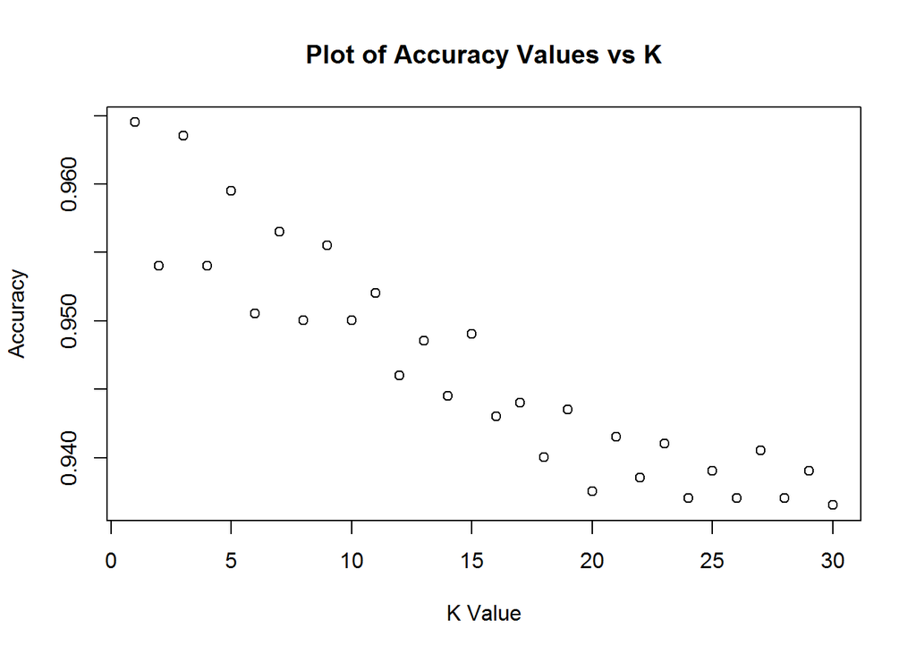

```r
# In other to view the trend in the data, we will make a Rough plot of the accuracies

plot(x = accuracy.df$k,y = accuracy.df$accuracy, main = "Plot of Accuracy Values vs K", xlab = "K Value", ylab = "Accuracy")
```

Response to Question 2: A choice of K that balances between over-fitting and ignoring the predictor information is K = 1, which results in the highest accuracy reading at 0.965.

```r
# Create the KNN model with K = 1 and only training and test data

knn_model2 <- knn(train = ml_1_Train_Norm[, -6], test = ml_1_Test_Norm[, -6],
          cl = ml_1_Train_Norm[, 6], k = 1, prob = TRUE)

# Confusion Matrix

predicted <- as.factor(knn_model2)
actual <- as.factor(ml_1_Test_Norm[, 6])

confusionMatrix(predicted, actual, positive = "1")
```

```
## Confusion Matrix and Statistics
##
##           Reference
## Prediction    0    1
##          0 1802   58
##          1   13  128
##
##                Accuracy : 0.9645
##                  95% CI : (0.9555, 0.9722)
##     No Information Rate : 0.907
##     P-Value [Acc > NIR] : < 2.2e-16
##
##                   Kappa : 0.764
##
##  Mcnemar's Test P-Value : 1.772e-07
##
##             Sensitivity : 0.68817
##             Specificity : 0.99284
##          Pos Pred Value : 0.90780
##          Neg Pred Value : 0.96882
##              Prevalence : 0.09295
##          Detection Rate : 0.06397
##    Detection Prevalence : 0.07046
##       Balanced Accuracy : 0.84050
##
##        'Positive' Class : 1
##
```

3. Confusion matrix of the KNN model using K = 1.

```r
# Runing KNN model on the customer profile with K = 1 value

knn_model_customer2 <- knn(train = ml_1_Train_Norm[, -6], test = customer,
          cl = ml_1_Train_Norm[, 6], k = 20, prob = TRUE)

# Return the value predicted by the model

as.data.frame(knn_model_customer2)
```

```
##   knn_model_customer2
## 1                   0
```

4. The prediction shows that this customer will still not accept the personal loan.

```r
# Set the seed for randomized functions

set.seed(100619)

# Split the data into 50% training data, 30% validation data, and 20% test data

ml_2_Index <- createDataPartition(ml_1$Age, p=0.2, list = F)

ml_2_Test <- ml_1[ml_2_Index,]

ml_2_Remaining <- ml_1[-ml_2_Index,]

ml_2_Index <- createDataPartition(ml_2_Remaining$Age, p=0.625, list = F)

ml_2_Train <- ml_2_Remaining[ml_2_Index,]

ml_2_Validation <- ml_2_Train[-ml_2_Index,]
```

We will repeat the normalization process in this new divided data, just as we did before.

```r
# Create a copy of the data sets for normalization

ml_2_Train_Norm <- ml_2_Train
ml_2_Test_Norm <- ml_2_Test
ml_2_Validation_Norm <- ml_2_Validation

# For centering and scaling the data we will create a model using preProcess function

Norm_Values <- preProcess(ml_2_Train[, c(1:5)], method = c("center", "scale"))

# Next we will now replace the numeric variables with the normalized and centered data

ml_2_Train_Norm[, c(1:5)] <- predict(Norm_Values, ml_2_Train[, c(1:5)])
ml_2_Test_Norm[, c(1:5)] <- predict(Norm_Values, ml_2_Test[, c(1:5)])
ml_2_Validation_Norm[, c(1:5)] <- predict(Norm_Values, ml_2_Validation[, c(1:5)])
```

Using the new divided data set,We will re-run the KNN model.

5. We expect the confusion matricies for the test data to have lower accuracy results because the data used had not been seen by the model while training it. But, we expect the confusion matrix for training data to be more accurate, because it has already seen the data that it is predicting. Based on our desire metric of comparison, we should compare the accuracy, precision, specificity and recall, or including any other metric of interest.

First confusion matrix is for the “test” data:

```r
# Create the KNN model with K = 1

knn_model_test <- knn(train = ml_2_Train_Norm[, -6], test = ml_2_Test_Norm[, -6],
          cl = ml_2_Train_Norm[, 6], k = 1, prob = TRUE)

# Confusion Matrix

predicted_test <- as.factor(knn_model_test)
actual_test <- as.factor(ml_2_Test_Norm[, 6])

confusionMatrix(predicted_test, actual_test, positive = "1")
```

```
## Confusion Matrix and Statistics
##
##           Reference
## Prediction   0   1
##          0 898  25
##          1   6  72
##
##                Accuracy : 0.969
##                  95% CI : (0.9563, 0.9789)
##     No Information Rate : 0.9031
##     P-Value [Acc > NIR] : 4.834e-16
##
##                   Kappa : 0.8061
##
##  Mcnemar's Test P-Value : 0.001225
##
##             Sensitivity : 0.74227
##             Specificity : 0.99336
##          Pos Pred Value : 0.92308
##          Neg Pred Value : 0.97291
##              Prevalence : 0.09690
##          Detection Rate : 0.07193
##    Detection Prevalence : 0.07792
##       Balanced Accuracy : 0.86782
##
##        'Positive' Class : 1
##
```

Second confusion matrix is for the “validation” data:

```r
# Create the KNN model with K = 1

knn_model_validation <- knn(train = ml_2_Train_Norm[, -6], test = ml_2_Validation_Norm[, -6],
          cl = ml_2_Train_Norm[, 6], k = 1, prob = TRUE)

# Confusion Matrix

predicted_validation <- as.factor(knn_model_validation)
actual_validation <- as.factor(ml_2_Validation_Norm[, 6])

confusionMatrix(predicted_validation, actual_validation, positive = "1")
```

```
## Confusion Matrix and Statistics
##
##           Reference
## Prediction   0   1
##          0 856   0
##          1   0  92
##
##                Accuracy : 1
##                  95% CI : (0.9961, 1)
##     No Information Rate : 0.903
##     P-Value [Acc > NIR] : < 2.2e-16
##
##                   Kappa : 1
##
##  Mcnemar's Test P-Value : NA
##
##             Sensitivity : 1.00000
##             Specificity : 1.00000
##          Pos Pred Value : 1.00000
##          Neg Pred Value : 1.00000
##              Prevalence : 0.09705
##          Detection Rate : 0.09705
##    Detection Prevalence : 0.09705
##       Balanced Accuracy : 1.00000
##
##        'Positive' Class : 1
##
```

Third confusion matrix is for the “train” data:

```r
# Creating KNN model with K = 1

knn_model_train <- knn(train = ml_2_Train_Norm[, -6], test = ml_2_Train_Norm[, -6],
          cl = ml_2_Train_Norm[, 6], k = 1, prob = TRUE)

# Confusion Matrix

predicted_train <- as.factor(knn_model_train)
actual_train <- as.factor(ml_2_Train_Norm[, 6])

confusionMatrix(predicted_train, actual_train, positive = "1")
```

```
## Confusion Matrix and Statistics
##
##           Reference
## Prediction    0    1
##          0 2250    0
##          1    0  251
##
##                Accuracy : 1
##                  95% CI : (0.9985, 1)
##     No Information Rate : 0.8996
##     P-Value [Acc > NIR] : < 2.2e-16
##
##                   Kappa : 1
##
##  Mcnemar's Test P-Value : NA
##
##             Sensitivity : 1.0000
##             Specificity : 1.0000
##          Pos Pred Value : 1.0000
##          Neg Pred Value : 1.0000
##              Prevalence : 0.1004
##          Detection Rate : 0.1004
##    Detection Prevalence : 0.1004
##       Balanced Accuracy : 1.0000
##
##        'Positive' Class : 1
##
```

The above confusion matricies shows that the predicted test data have a lower accuracy reading than the training data. Both the validation data and training data had an accuracy reading of 1.0; although, large amounts of normalized data do behave differently.